# POSC 8410 Midterm: Worked Solutions

Exam given Monday, October 19, 2026

# Question 1: Describing Data (11 points)

A researcher records how much money five House challengers raised in the first quarter of an election year, in thousands of dollars: 2, 3, 5, 6, 34.

## (a) Mean, median, and sample standard deviation (5 points)

**Mean.** Add the values and divide by $n = 5$:
$$\bar{x} = \frac{2 + 3 + 5 + 6 + 34}{5} = \frac{50}{5} = 10$$

**Median.** The values are already in order. With five values, the median is the third one: **5**.

**Sample standard deviation.** A small table keeps the arithmetic organized: subtract the mean from each value, square each deviation, and add.

| $x_i$ | $x_i - \bar{x}$ | $(x_i - \bar{x})^2$ |
| --- | --- | --- |
| 2 | $-8$ | 64 |
| 3 | $-7$ | 49 |
| 5 | $-5$ | 25 |
| 6 | $-4$ | 16 |
| 34 | $24$ | 576 |
| **Sum** | **0** | **730** |

The deviations always sum to zero, which makes a handy check on your arithmetic. Divide the sum of squares by $n - 1 = 4$, then take the square root:
$$s^2 = \frac{730}{4} = 182.5, \qquad s = \sqrt{182.5} \approx 13.51$$

**Answer:** mean = 10, median = 5, and $s \approx 13.51$ (thousands of dollars).

**Dividing by $n$ instead of $n - 1$** gives $\sqrt{730/5} \approx 12.08$. The sample variance divides by $n - 1$ because the deviations are measured from $\bar{x}$, which is computed from these same five values and so sits closer to them than the true mean would. Dividing by $n - 1$ corrects for that.

**Stopping at the variance.** 182.5 is the variance, measured in *squared* thousands of dollars. The standard deviation is its square root, back in thousands of dollars.

**Check it in R**

```r
raised <- c(2, 3, 5, 6, 34)
mean(raised)
## [1] 10
median(raised)
## [1] 5
sd(raised)        # sd() divides by n - 1
## [1] 13.50926
```

## (b) The typical challenger (3 points)

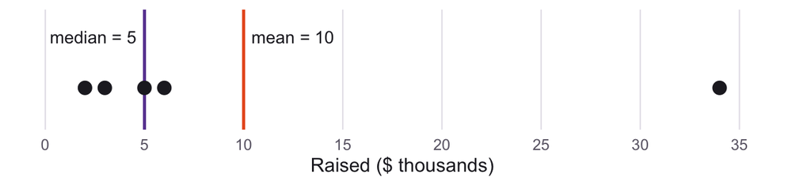

The **median** better describes the typical challenger. Four of the five challengers raised $6,000 or less, yet the mean of $10,000 is above all four, because the single $34,000 challenger pulls it up. The median does not care how far that top value is from the rest. If the top challenger had raised $340,000 instead, the median would still be 5, while the mean would jump to 71.2.

The gap between them describes the shape. When the mean is well above the median, the distribution is **right-skewed**: most values are bunched at the low end, with a long tail of a few large values. Campaign money, income, and wealth typically look like this.

**Answer:** the median (5). The mean is above the median because one large value pulls it up, so the distribution is right-skewed.

## (c) Averaging a party identification scale (3 points)

The scale is **ordinal**. Its categories have a clear order, from Strong Democrat to Strong Republican, but nothing guarantees that the steps between them are the same size.

Reporting a mean treats the variable as if it were interval: it **assumes the distances between adjacent categories are equal**. Averaging says that moving from Strong Democrat (1) to Weak Democrat (2) is the same size change as moving from Independent (4) to Lean Republican (5). That can be a reasonable approximation, and researchers average party identification all the time, but it is an assumption. A mean of, say, 3.9 is only meaningful if it holds.

**Answer:** ordinal. Reporting the mean assumes equal spacing between adjacent categories, as if the scale were interval. Note, I also accepted categorical, as I can by the argument that this is not necessarily ordered.

# Question 2: Flagging Double Voters (16 points)

A state election office uses a matching algorithm to flag voters who may have voted twice. 1 in every 10,000 voters actually voted twice. If a voter did vote twice, the algorithm flags them 95% of the time. If a voter did not vote twice, it still flags them 0.2% of the time. Let $D$ be the event that a voter voted twice, and $F$ the event that the algorithm flags them.

Start by translating into probability notation. Notice that the 95% and the 0.2% both condition on *the truth* (whether the person voted twice):
$$P(D) = 0.0001, \qquad P(F \mid D) = 0.95, \qquad P(F \mid D^c) = 0.002$$

## (a) Counting it out in 1,000,000 voters (4 points)

Split the population by the truth first, then apply each flagging rate to its own group:

- **Voted twice:** $1{,}000{,}000 \times 0.0001 = 100$ voters. The algorithm flags $0.95 \times 100 = 95$ of them.
- **Did not vote twice:** $1{,}000{,}000 - 100 = 999{,}900$ voters. The algorithm flags $0.002 \times 999{,}900 = 1{,}999.8 \approx 2{,}000$ of them.
- **Flagged in total:** $95 + 1{,}999.8 \approx 2{,}095$.

|  | Flagged | Not flagged | Total |
| --- | --- | --- | --- |
| Voted twice ($D$) | 95 | 5 | 100 |
| Did not vote twice ($D^c$) | 2,000 | 997,900 | 999,900 |
| **Total** | **2,095** | **997,905** | **1,000,000** |

**Answer:** 100 double voters, 95 of them flagged; about 2,000 honest voters flagged; about 2,095 flagged in total.

## (b) The probability that a flagged voter voted twice (4 points)

We want $P(D \mid F)$: we know the person was flagged, and we ask how likely it is that they voted twice. There are two routes to the same answer.

**Route 1: use the counts.** Restrict attention to the flagged column of the table. Of about 2,095 flagged voters, 95 actually voted twice:
$$P(D \mid F) = \frac{95}{2{,}094.8} \approx 0.045$$

**Route 2: Bayes’ rule.** The denominator is the law of total probability, which adds up the two ways to get flagged:
$$\begin{aligned}
P(D \mid F) &= \frac{P(F \mid D)\,P(D)}{P(F \mid D)\,P(D) + P(F \mid D^c)\,P(D^c)} \\[6pt]
&= \frac{(0.95)(0.0001)}{(0.95)(0.0001) + (0.002)(0.9999)} \\[6pt]
&= \frac{0.000095}{0.0020948} \approx 0.045
\end{aligned}$$

**Answer:** $P(D \mid F) \approx 0.045$. Only about 1 in 22 flagged voters actually voted twice; more than 95% of the list are false flags.

**Check it in R**

```r
p_D       <- 1 / 10000   # P(D)
p_F_D     <- 0.95        # P(F | D)
p_F_notD  <- 0.002       # P(F | not D)

p_F <- p_F_D * p_D + p_F_notD * (1 - p_D)   # law of total probability
p_F_D * p_D / p_F                           # Bayes' rule: P(D | F)
## [1] 0.04535039
```

## (c) What “95% accurate” means (4 points)

The 95% is $P(F \mid D)$, the **detection rate**: among people who *did* vote twice, the share the algorithm catches.

The legislator’s claim is about $P(D \mid F)$: among people *on the list*, the share who voted twice. These condition on different things. One starts from the truth and asks about the flag; the other starts from the flag and asks about the truth. As we saw in class, $P(A \mid B) \neq P(B \mid A)$ in general. Here, the claim is off by a factor of about 20: the true probability is 4.5%, not 95%.

The two are so different because **double voting is extremely rare**. There are 10,000 honest voters for every double voter. A false-flag rate of only 0.2%, applied to almost a million honest voters, produces about 2,000 false flags. That swamps the 95 real ones. This is the same base-rate problem as the disease-screening example from class: an accurate test for a rare condition produces mostly false positives. Taken at face value, the legislator’s reasoning would conclude that about 2,000 people voted twice, when the list contains about 95.

**Answer:** the 95% is $P(F \mid D)$; the claim needs $P(D \mid F) \approx 0.045$. They differ because the base rate is tiny, so false flags from the huge honest population outnumber true flags about 20 to 1.

## (d) Which upgrade helps more? (4 points)

**Cut the false-flag rate.** Rerun the counts from part (a) under each upgrade:

| Scenario | True flags | False flags | $P(D \mid F)$ |
| --- | --- | --- | --- |
| Current algorithm | 95 | 2,000 | 0.045 |
| Detection raised to 100% | 100 | 2,000 | 0.048 |
| False-flag rate cut to 0.02% | 95 | 200 | 0.322 |

**The intuition.** $P(D \mid F)$ is true flags divided by all flags. True flags come from a pool of only 100 double voters, so even perfect detection can add at most 5 of them. False flags come from a pool of 999,900 honest voters, so cutting the false-flag rate tenfold removes about 1,800 of them. When the base rate is tiny, the false-positive rate, not the detection rate, decides whether a positive result can be trusted.

**Answer:** cutting the false-flag rate, which raises $P(D \mid F)$ from about 0.045 to about 0.32; perfect detection only reaches about 0.048. False flags come from the enormous honest population, so they dominate the list.

**Check it in R**

```r
bayes <- function(detect, false_flag, p_D = 1 / 10000) {
  detect * p_D / (detect * p_D + false_flag * (1 - p_D))
}
bayes(0.95, 0.002)    # current
## [1] 0.04535039
bayes(1.00, 0.002)    # perfect detection
## [1] 0.04762358
bayes(0.95, 0.0002)   # fewer false flags
## [1] 0.3220557
```

# Question 3: Confounders and Colliders (15 points)

For each scenario: (i) name the third variable; (ii) say whether it is a confounder or a collider; and (iii) say whether the researcher should condition on it (control for it, or restrict the sample by it), and what goes wrong with the wrong choice.

The whole question turns on **which way the arrows point** between the third variable and the two variables of interest:

|  | Confounder | Collider |
| --- | --- | --- |
| Structure | **Causes** both: $X \leftarrow C \rightarrow Y$ | **Caused by** both: $X \rightarrow C \leftarrow Y$ |
| If you do **not** condition on it | Spurious association | No problem |
| If you **do** condition on it | No problem | Spurious association |

Remember that **restricting your sample is conditioning.** Looking only at published studies, or only at winners, conditions on publication or on winning just as surely as adding a control variable does.

## (a) Published studies (5 points)

**Third variable:** whether a study is published.

**Type:** a **collider**. Both sample size and effect size cause publication:
$$\text{Sample size} \rightarrow \text{Published} \leftarrow \text{Effect size}$$

**Should the researcher condition on it? No.** Looking only at published studies conditions on the collider. A small study with a small effect never gets published, so the only small studies that make it into journals are those that happened to find large effects. Among published studies, small samples therefore go with large effects, even though across all studies the two are unrelated. To learn whether sample size and effect size are actually related, the researcher would need all the studies conducted, for example from a registry of preregistered studies, not just the published ones. This is the same structure as the admissions example from class, where test scores and essays look negatively related among admitted students only.

## (b) Police and crime (5 points)

**Third variable:** city size (population).

**Type:** a **confounder**. City size causes both:
$$\text{Police officers} \leftarrow \text{City size} \rightarrow \text{Crime}$$

**Should the researcher condition on it? Yes.** Compare cities of similar size, or use per-capita rates (officers per 1,000 residents, crimes per 1,000 residents). Without that, big cities have more of everything, so police and crime rise together even if police have no effect on crime, or even reduce it. The columnist has mistaken confounding for causation. (Reverse causation is a second problem: cities with more crime hire more officers. But the third variable the scenario describes is city size.)

## (c) Studying only winners (5 points)

**Third variable:** winning the election.

**Type:** a **collider**. Both experience and money cause winning:
$$\text{Experience} \rightarrow \text{Won} \leftarrow \text{Money raised}$$

**Should the researcher condition on it? No.** She should study all candidates, winners and losers. Among winners only, a first-time candidate who won probably needed a lot of money to overcome their inexperience, while an experienced candidate could win with less. So within the sample of winners, experience and money look negatively related, even if among all candidates they are unrelated, or experienced candidates actually raise *more*. Her conclusion is an artifact of how she chose her sample.

# Question 4: Four Swing Districts (15 points)

A party is competing in four toss-up House districts, with a 0.6 probability of winning each one. Let $X$ be the number of these four seats the party wins.

## (a) Expected seats (2 points)

Write the seat count as a sum of four win indicators, $X = W_1 + W_2 + W_3 + W_4$, where $W_i = 1$ if the party wins district $i$. Each $W_i$ is Bernoulli(0.6), so $E[W_i] = 0.6$. By linearity of expectation,
$$E[X] = E[W_1] + E[W_2] + E[W_3] + E[W_4] = 4 \times 0.6 = 2.4$$

**Independence is not needed.** Linearity of expectation holds whether or not the races are related. This is the House forecasting example from class: expected seats are always the sum of the win probabilities.

**Answer:** $E[X] = 2.4$ seats, with or without independence, by linearity of expectation.

## (b) Independent races (5 points)

Four independent trials, each with the same success probability, and $X$ counts the successes: $X \sim \text{Binomial}(n = 4,\ p = 0.6)$.

**$P(X \geq 3)$** means winning exactly 3 *or* all 4:
$$P(X = 3) = \binom{4}{3}(0.6)^3(0.4)^1 = 4 \times 0.216 \times 0.4 = 0.3456$$
$$P(X = 4) = \binom{4}{4}(0.6)^4 = 0.1296$$
$$P(X \geq 3) = 0.3456 + 0.1296 = 0.4752$$

The $\binom{4}{3} = 4$ counts the four different ways to win exactly three seats, one for each district you could lose.

**Standard deviation:**
$$\text{Var}(X) = np(1-p) = 4 \times 0.6 \times 0.4 = 0.96, \qquad SD(X) = \sqrt{0.96} \approx 0.98$$

**Answer:** $X \sim \text{Binomial}(4, 0.6)$; $P(X \geq 3) = 0.4752$; $SD(X) \approx 0.98$ seats.

**Leaving out $\binom{4}{3}$.** $(0.6)^3(0.4) = 0.0864$ is the probability of *one particular* sequence, such as win, win, win, lose. Four different sequences each give exactly three wins, so multiply by 4.

## (c) One national tide (4 points)

$X$ can now take only two values:

| $x$ | 0 | 4 |
| --- | --- | --- |
| $P(X = x)$ | 0.4 | 0.6 |

$$E[X] = 0(0.4) + 4(0.6) = 2.4$$
$$E[X^2] = 0^2(0.4) + 4^2(0.6) = 9.6$$
$$\text{Var}(X) = E[X^2] - (E[X])^2 = 9.6 - 2.4^2 = 9.6 - 5.76 = 3.84, \qquad SD(X) = \sqrt{3.84} = 1.96$$

The deviation form gives the same variance: $(0 - 2.4)^2(0.4) + (4 - 2.4)^2(0.6) = 2.304 + 1.536 = 3.84$.

**Answer:** $P(X = 0) = 0.4$, $P(X = 4) = 0.6$; $E[X] = 2.4$; $SD(X) = 1.96$ seats.

## (d) Which world is riskier? (4 points)

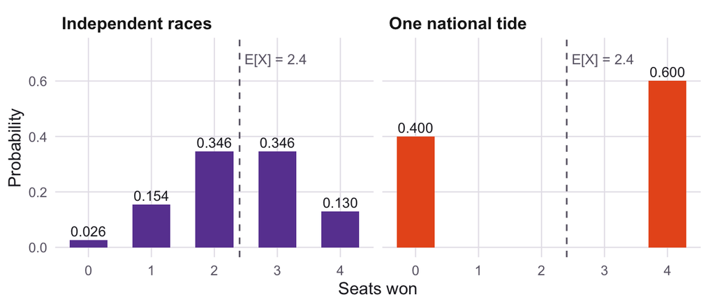

**The national-tide world is riskier.** Expected seats are identical in both worlds, 2.4, but the spread is not: the standard deviation doubles, from 0.98 to 1.96, and the variance quadruples, from 0.96 to 3.84. The probability of losing all four seats shows the difference most clearly:

- **Independent races:** $P(X = 0) = 0.4^4 = 0.0256$, about 1 chance in 39.
- **National tide:** $P(X = 0) = 0.4$, a 40% chance of being wiped out.

**Check it in R**

```r
dbinom(0:4, size = 4, prob = 0.6)            # the full binomial PMF
## [1] 0.0256 0.1536 0.3456 0.3456 0.1296
sum(dbinom(3:4, size = 4, prob = 0.6))       # P(X >= 3)
## [1] 0.4752
sqrt(4 * 0.6 * 0.4)                          # SD, independent races
## [1] 0.9797959
sqrt(4^2 * 0.6 - 2.4^2)                      # SD, national tide
## [1] 1.959592
```

# Question 5: Continuous Distributions and Marginal Effects (11 points)

County turnout is approximately normal, with a mean of 62% and a standard deviation of 8 percentage points.

## (a) Share of counties between 46% and 78% (3 points)

Convert each endpoint to a $z$-score, the number of standard deviations from the mean:
$$z_{46} = \frac{46 - 62}{8} = -2, \qquad z_{78} = \frac{78 - 62}{8} = +2$$

The interval is the mean plus or minus two standard deviations. By the 68–95–99.7 rule, that covers about **95%** of counties (95.4%, to be precise).

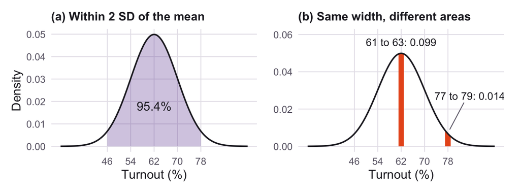

**Answer:** about 95%, since 46% and 78% are two standard deviations below and above the mean.

## (b) The probability of exactly 62% (3 points)

**The probability is zero.** Turnout is continuous, and for a continuous variable, probability is the *area under the density curve over an interval*. A single point has no width, so it has no area. Probability zero does not mean impossible: some county has turnout of some exact value, but any one exact value has probability zero.

**“Near 62% is most common”** is a statement about the **density**, which is probability per unit of turnout, not probability itself. The density is highest at 62, so an interval around 62 holds more area than an equally wide interval anywhere else. The right panel above shows this: the interval from 61% to 63% holds probability 0.099, while the equally wide interval from 77% to 79% holds only 0.014. Probability requires an interval; “most common” compares intervals.

**Answer:** zero, because a single point has no area under the density. “Near 62% is most common” means the density peaks at 62, so intervals around 62 contain more probability than equally wide intervals elsewhere.

## (c) Marginal effects of income (5 points)

The derivative was given, so the computation is just plugging in:
$$\begin{aligned}
\text{At } X = 25: &\quad \frac{10}{25} = 0.4 \\[6pt]
\text{At } X = 100: &\quad \frac{10}{100} = 0.1
\end{aligned}$$

**Units matter for the interpretation.** Turnout is in percentage points and $X$ is in thousands of dollars, so the marginal effect is in *percentage points per $1,000 of median income*.

- **At $25,000:** among counties with median income around $25,000, a county with $1,000 more median income has expected turnout about **0.4 percentage points higher**.
- **At $100,000:** among counties around $100,000, the same $1,000 difference goes with only about **0.1 points** higher expected turnout.

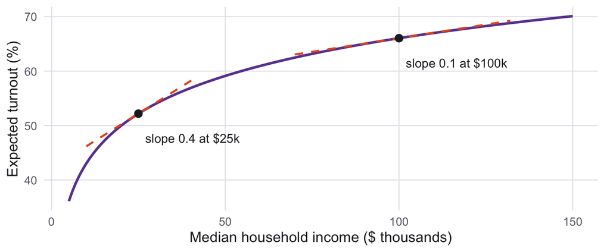

**The function is concave**: its slope, $10/X$, shrinks as income rises, so the curve bends downward. Substantively, that means **diminishing returns**. Income differences are associated with much larger turnout differences among poorer counties than among richer ones: a $1,000 difference matters four times as much at $25,000 as at $100,000.

# Question 6: Party and Policy (12 points)

Let $X = 1$ for Republicans and $X = 0$ for Democrats, and $Y = 1$ if the respondent supports a federal carbon tax. The joint PMF is in the four inner cells below; the row and column totals (the margins) are added in bold.

|  | $Y = 0$ (oppose) | $Y = 1$ (support) | **Total** |
| --- | --- | --- | --- |
| $X = 0$ (Democrat) | 0.12 | 0.48 | **0.60** |
| $X = 1$ (Republican) | 0.28 | 0.12 | **0.40** |
| **Total** | **0.40** | **0.60** | **1.00** |

## (a) Marginal probabilities (3 points)

Sum across the row or down the column:
$$P(X = 1) = 0.28 + 0.12 = 0.40, \qquad P(Y = 1) = 0.48 + 0.12 = 0.60$$

**Answer:** $P(X = 1) = 0.40$ (40% of respondents are Republicans), and $P(Y = 1) = 0.60$ (60% support the tax).

## (b) Conditional probabilities and independence (3 points)

Conditioning on party restricts attention to one row, then renormalizes it by the row total:
$$\begin{aligned}
P(Y = 1 \mid X = 0) &= \frac{P(X = 0, Y = 1)}{P(X = 0)} = \frac{0.48}{0.60} = 0.80 \\[6pt]
P(Y = 1 \mid X = 1) &= \frac{P(X = 1, Y = 1)}{P(X = 1)} = \frac{0.12}{0.40} = 0.30
\end{aligned}$$

**$X$ and $Y$ are not independent.** If they were, knowing someone’s party would not change the probability that they support the tax: both conditionals would equal $P(Y = 1) = 0.60$. Instead, 80% of Democrats and 30% of Republicans support it. Equivalently, check one cell against the product of its margins: $P(X = 1, Y = 1) = 0.12$, but $P(X = 1)\,P(Y = 1) = 0.40 \times 0.60 = 0.24$.

## (c) Covariance and the regression slope (3 points)

Use the shortcut $\text{Cov}(X, Y) = E[XY] - E[X]\,E[Y]$.

- For 0/1 variables the means are probabilities: $E[X] = 0.40$, $E[Y] = 0.60$.
- $XY$ equals 1 only when both $X = 1$ and $Y = 1$, and 0 otherwise. So $E[XY] = P(X = 1, Y = 1) = 0.12$.

$$\text{Cov}(X, Y) = 0.12 - (0.40)(0.60) = 0.12 - 0.24 = -0.12$$

$X$ is Bernoulli(0.4), so $\text{Var}(X) = p(1 - p) = 0.40 \times 0.60 = 0.24$, and
$$\beta_1 = \frac{\text{Cov}(X, Y)}{\text{Var}(X)} = \frac{-0.12}{0.24} = -0.50$$

If you used the definition $E[(X - \mu_X)(Y - \mu_Y)]$ instead, you sum over all four cells and get the same answer:
$$\begin{aligned}
&(-0.4)(-0.6)(0.12) + (-0.4)(0.4)(0.48) + (0.6)(-0.6)(0.28) + (0.6)(0.4)(0.12) \\[4pt]
&\quad = 0.0288 - 0.0768 - 0.1008 + 0.0288 = -0.12
\end{aligned}$$

The negative sign says the variables move in opposite directions: being Republican ($X = 1$) goes with not supporting the tax ($Y = 0$).

**Answer:** $\text{Cov}(X, Y) = -0.12$ and $\beta_1 = -0.50$.

## (d) What the slope measures (3 points)

Compare the slope to the conditional probabilities from part (b):
$$\beta_1 = -0.50 = 0.30 - 0.80 = P(Y = 1 \mid X = 1) - P(Y = 1 \mid X = 0)$$

**When $X$ is binary, the regression slope is the difference in the conditional means of $Y$ between the two groups.** Because $Y$ is also binary, those conditional means are conditional probabilities: $E[Y \mid X = x] = P(Y = 1 \mid X = x)$.

In words, **Republicans are 50 percentage points less likely than Democrats to support the carbon tax.** Like any conditional expectation, this describes a difference between groups; it is not, on its own, the causal effect of party.

**Answer:** $\beta_1$ equals the difference in support rates, $0.30 - 0.80$: Republicans are 50 percentage points less likely than Democrats to support the tax.

**Check it in R**

```r
# Build a population with exactly these joint proportions, then run the regression
pop <- data.frame(
  X = rep(c(0, 0, 1, 1), times = c(12, 48, 28, 12)),
  Y = rep(c(0, 1, 0, 1), times = c(12, 48, 28, 12))
)
tapply(pop$Y, pop$X, mean)    # P(Y = 1 | X = 0) and P(Y = 1 | X = 1)
##   0   1
## 0.8 0.3
coef(lm(Y ~ X, data = pop))   # the slope is the difference: -0.5
## (Intercept)           X
##         0.8        -0.5
```

# Question 7: Are Partisans Growing Colder? (20 points)

Partisans rate the *opposing* party on a 0–100 feeling thermometer. Treat these as population values.

| Group | 2004 share | 2004 mean | 2024 share | 2024 mean |
| --- | --- | --- | --- | --- |
| Strong partisans | 0.30 | 25 | 0.50 | 26 |
| Weak partisans | 0.40 | 40 | 0.30 | 42 |
| Leaning independents | 0.30 | 45 | 0.20 | 47 |

## (a) The overall mean in each year (4 points)

The **law of iterated expectations** says the overall mean is the group means weighted by the group shares:
$$E[Y] = E\big[E[Y \mid X]\big] = \sum_x E[Y \mid X = x]\,P(X = x)$$

$$2004: \quad 0.30(25) + 0.40(40) + 0.30(45) = 7.5 + 16 + 13.5 = 37.0$$
$$2024: \quad 0.50(26) + 0.30(42) + 0.20(47) = 13 + 12.6 + 9.4 = 35.0$$

**Answer:** 37.0 in 2004 and 35.0 in 2024, using the law of iterated expectations (group means weighted by group shares).

**Averaging the group means without weights.** $(26 + 42 + 47)/3 = 38.3$ treats the three groups as equally large, but strong partisans are half the population in 2024. This is the same mistake as averaging county election results as though every county had the same number of people.

## (b) Holding the group means at their 2004 levels (4 points)

Keep the **2004 means** but use the **2024 shares**:
$$0.50(25) + 0.30(40) + 0.20(45) = 12.5 + 12 + 9 = 33.5$$

This counterfactual isolates the effect of the changing mix of people: if no group’s attitudes had moved at all, the shift in group sizes alone would have pulled the average from 37.0 down to 33.5.

**Answer:** 33.5.

## (c) Did partisans grow colder? (7 points)

**The decomposition.** Parts (a) and (b) give three numbers: 37.0 (2004), 33.5 (2024 shares with 2004 means), and 35.0 (2024). Step through them:

| Step | Calculation | Change |
| --- | --- | --- |
| Changing shares (composition) | $33.5 - 37.0$ | $-3.5$ |
| Changing group means | $35.0 - 33.5$ | $+1.5$ |
| **Total change** | $35.0 - 37.0$ | $\mathbf{-2.0}$ |

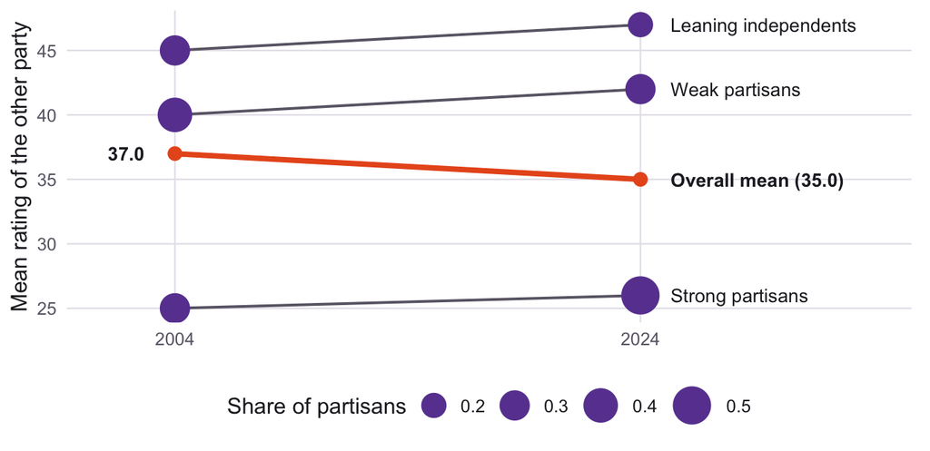

**Evaluating the claim.** The figure shows the puzzle at a glance: every gray line slopes up, but the orange line slopes down.

- **Overall, the average fell**, from 37.0 to 35.0. It is true that the average partisan in 2024 rates the other party less warmly than the average partisan in 2004 did.
- **Within every group, ratings rose.** Strong partisans warmed by 1 point, weak partisans by 2, and leaners by 2. No type of partisan grew colder.
- **Why the two differ: composition.** The coldest group, strong partisans, grew from 30% to 50% of all partisans, while the warmer groups shrank. Because the overall mean is a weighted average of the group means, shifting weight toward the coldest group pulled it down by 3.5 points, more than offsetting the 1.5 points of within-group warming. This is the composition effect that the law of iterated expectations warns about, and the same mechanism as Simpson’s paradox in the Berkeley admissions data: an aggregate trend that runs opposite to the trend inside every group.

It depends on what the columnist means. If the claim is “the average partisan rates the other side lower than before,” it is correct. If it is “partisans have become more hostile,” which is the natural reading, it is misleading: partisans of every type grew slightly *warmer*. What changed is the mix: far more people are now strong partisans. A more accurate headline would be “Strong partisanship is on the rise, though partisans of each type are slightly warmer toward the other side.”

These numbers cannot tell us what happened to individuals. If many people moved from weak to strong partisanship and cooled as they did, those individuals did grow colder. Answering that would require following the same people over time, in a panel survey.

**Answer:** the overall mean fell by 2.0 points: $-3.5$ from composition and $+1.5$ from within-group change. The overall mean fell, but every group grew warmer; the decline is entirely due to the growing share of strong partisans, the coldest group. The claim holds for the average partisan but not for partisans of any given type.

If you split the change the other way around, using 2004 shares as the reference (2004 shares with 2024 means is 38.7), you get $-3.7$ for composition and $+1.7$ for the group means. The exact split depends on which year you hold fixed, but the conclusion is the same.

## (d) Regression on group dummies (5 points)

**The coefficients.** With a categorical $X$, regression reproduces the conditional expectation function exactly. The intercept is the baseline group’s mean, and each dummy’s coefficient is that group’s difference from the baseline:
$$\beta_0 = 26, \qquad \beta_1 = 42 - 26 = 16, \qquad \beta_2 = 47 - 26 = 21$$

Check: for a weak partisan, the prediction is $\beta_0 + \beta_1 = 26 + 16 = 42$, which is the weak partisans’ mean.

**The causal reading is not justified.** $\beta_1 = 16$ says that, in 2024, weak partisans rate the other party 16 points warmer *on average* than strong partisans. That is a descriptive difference between two groups. It does not tell us what would happen if a particular strong partisan became a weak one:

- **Confounding.** Strong and weak partisans differ in many other ways that also shape how they feel about the other party: political interest, ideological extremity, media diet, age, and more. Some or all of the 16 points may reflect those differences rather than partisanship itself.
- **Reverse causation.** Disliking the other party may be part of what *makes* someone a strong partisan, rather than the other way around.

**Check it in R**

```r
share24 <- c(strong = 0.50, weak = 0.30, lean = 0.20)
mean24  <- c(strong = 26,   weak = 42,   lean = 47)
share04 <- c(strong = 0.30, weak = 0.40, lean = 0.30)
mean04  <- c(strong = 25,   weak = 40,   lean = 45)

sum(share04 * mean04)    # 2004 overall
## [1] 37
sum(share24 * mean24)    # 2024 overall
## [1] 35
sum(share24 * mean04)    # 2024 shares, 2004 means
## [1] 33.5

# Regression on dummies: build 100 people with the 2024 shares and means
pop <- data.frame(group = factor(rep(names(share24), times = c(50, 30, 20)),
                                 levels = c("strong", "weak", "lean")))
pop$rating <- mean24[as.character(pop$group)]
coef(lm(rating ~ group, data = pop))
## (Intercept)   groupweak   grouplean
##          26          16          21
```